# 2o examen parcial

### Tópicos Selectos De Matemáticas Aplicadas II: Análisis de Datos con Python

#### 18 de julio de 2025

Alan Badillo Salas

```python
import numpy
import pandas

import matplotlib.pyplot as pyplot
import seaborn
```

### **Ejercicio 1. (50 puntos)**

Cargue los datos de incidentes viales reportados por C5 (*Viales_2022_2024.csv* en Github) y realice lo siguiente:

**a)** Obtenga un Dataframe con los tipos de incidentes y su frecuencia. Obtenga un gráfico que ilustre esto.

**b)** Obtenga un Dataframe con los incidentes y su frecuencia. Obtenga un gráfico que ilustre esto.

**c)** Obtenga un gráfico de barras que iluste el número de incidentes por alcaldía (columna 'alcaldia_inicio').

**d)** Obtenga una serie temporal con el número de atropellados por semana y grafique la serie.

**e)** Obtenga un mapa de calor (HeatMap) que muestre la ubicación geográfica de los reportes de personas atropelladas, utilizando las coordenadas de latitud y longitud asociadas a cada incidente.

```python
accidentes = pandas.read_csv("Viales_2022_2024.csv")

accidentes.head()
```

|  | fecha_creacion | hora_creacion | tipo_incidente_c4 | incidente_c4 | alcaldia_inicio | clas_con_f_alarma | tipo_entrada | alcaldia_catalogo | colonia_catalogo | longitud | latitud |
| --- | --- | --- | --- | --- | --- | --- | --- | --- | --- | --- | --- |
| 0 | 2021-12-29 | 23:21:20 | Lesionado | Atropellado | NaN | URGENCIAS MEDICAS | BOTÓN DE AUXILIO | Cuauhtémoc | Roma Norte | -99.163670 | 19.421610 |
| 1 | 2022-01-01 | 09:51:53 | Accidente | Motociclista | CUAUHTEMOC | URGENCIAS MEDICAS | RADIO | Miguel Hidalgo | Tlaxpana | -99.165781 | 19.443649 |
| 2 | 2022-01-01 | 09:56:54 | Accidente | Choque sin lesionados | GUSTAVO A. MADERO | EMERGENCIA | BOTÓN DE AUXILIO | Gustavo A. Madero | C T M Aragon | -99.054690 | 19.451630 |
| 3 | 2021-12-31 | 21:47:36 | Accidente | Motociclista | XOCHIMILCO | URGENCIAS MEDICAS | BOTÓN DE AUXILIO | Xochimilco | Cerrillos Primera Seccion | -99.020370 | 19.245690 |
| 4 | 2022-01-01 | 03:43:56 | Accidente | Motociclista | IZTAPALAPA | URGENCIAS MEDICAS | BOTÓN DE AUXILIO | Iztapalapa | Celoalliotli | -99.071140 | 19.291070 |

```python
accidentes["tipo_incidente_c4"].value_counts()
```

```
tipo_incidente_c4
Accidente              150097
Lesionado               17356
Cadáver                   353
Detención ciudadana       120
Mi Calle                  105
Sismo                      36
Mi Taxi                    20
Name: count, dtype: int64
```

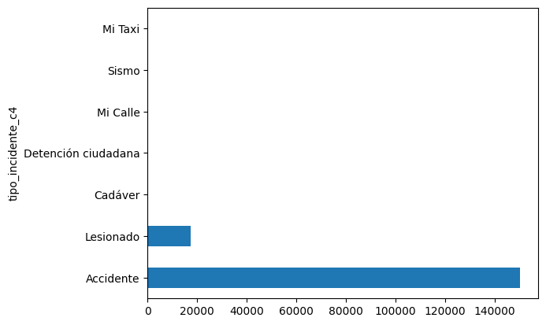

```python
accidentes["tipo_incidente_c4"].value_counts().plot.barh()
```

```python
accidentes["incidente_c4"].value_counts()
```

```
incidente_c4
Choque sin lesionados               77067
Choque con lesionados               48834
Atropellado                         17559
Motociclista                        16753
Volcadura                            3010
Ciclista                             2241
Persona atrapada / desbarrancada      914
Vehículo atrapadovarado               700
Choque con prensados                  334
Accidente automovilístico             270
Incidente de tránsito                 125
Otros                                  86
Vehiculo desbarrancado                 80
Monopatín                              72
Ferroviario                            32
Persona atropellada                    10
Name: count, dtype: int64
```

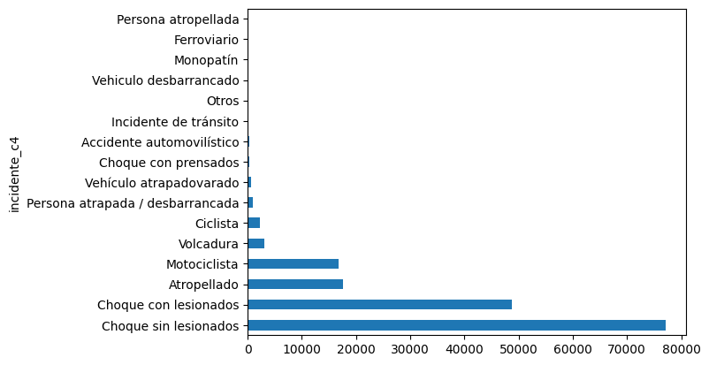

```python
accidentes["incidente_c4"].value_counts().plot.barh()
```

```python
accidentes["alcaldia_inicio"].fillna("NO ESPECIFICADA").value_counts()
```

```
alcaldia_inicio
IZTAPALAPA                27437
GUSTAVO A. MADERO         18846
CUAUHTEMOC                17461
COYOACAN                  12363
VENUSTIANO CARRANZA       12217
BENITO JUAREZ             12147
TLALPAN                   12092
ALVARO OBREGON            11368
MIGUEL HIDALGO            10309
IZTACALCO                  8206
AZCAPOTZALCO               6998
XOCHIMILCO                 6545
TLAHUAC                    5018
CUAJIMALPA DE MORELOS      3205
LA MAGDALENA CONTRERAS     2680
MILPA ALTA                 1183
NO ESPECIFICADA              12
Name: count, dtype: int64
```

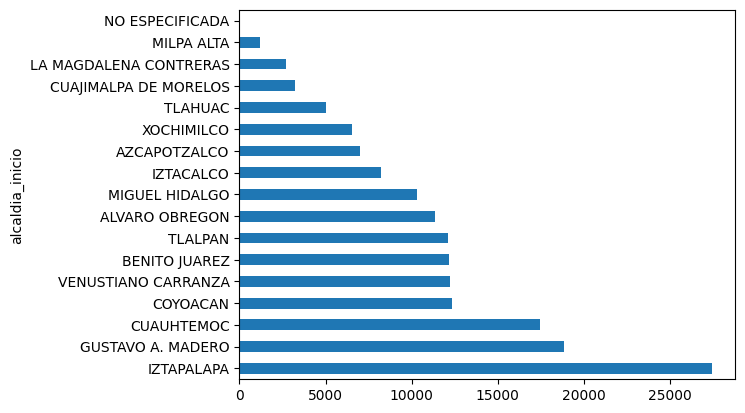

```python
accidentes["alcaldia_inicio"].fillna("NO ESPECIFICADA").value_counts().plot.barh()
```

```python
atropellos = accidentes[["fecha_creacion", "incidente_c4"]].sort_values("fecha_creacion").set_index("fecha_creacion").copy()
atropellos["incidente_c4"] = atropellos["incidente_c4"].map({ "Atropellado": 1 }).fillna(0)
atropellos.index = pandas.to_datetime(atropellos.index)
atropellos = atropellos.resample("W")
atropellos.size().head()
```

```
fecha_creacion
2022-01-02     282
2022-01-09    1134
2022-01-16    1134
2022-01-23    1118
2022-01-30    1118
Freq: W-SUN, dtype: int64
```

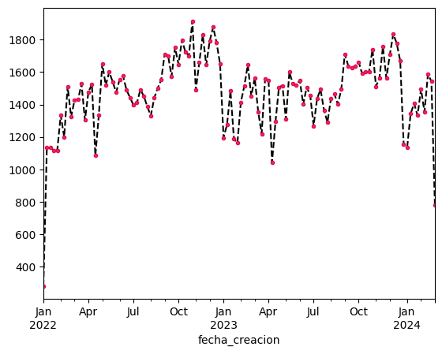

```python
atropellos.size().plot(marker=".", linestyle="--", color="black", mec="crimson", mfc="deeppink")
```

```python
accidentes_atropellos = accidentes[["fecha_creacion", "alcaldia_inicio", "incidente_c4", "latitud", "longitud"]].sort_values("fecha_creacion")

accidentes_atropellos = accidentes_atropellos[accidentes_atropellos["incidente_c4"] == "Atropellado"].drop("incidente_c4", axis=1).set_index("fecha_creacion").copy()

accidentes_atropellos["alcaldia_inicio"] = accidentes_atropellos["alcaldia_inicio"].fillna("NO ESPECIFICADA")

accidentes_atropellos.index = pandas.to_datetime(accidentes_atropellos.index)

accidentes_atropellos
```

| fecha_creacion | alcaldia_inicio | latitud | longitud |
| --- | --- | --- | --- |
| 2021-12-29 | NO ESPECIFICADA | 19.421610 | -99.163670 |
| 2021-12-31 | CUAUHTEMOC | 19.425772 | -99.131386 |
| 2022-01-01 | AZCAPOTZALCO | 19.500440 | -99.203555 |
| 2022-01-01 | XOCHIMILCO | 19.253871 | -99.011781 |
| 2022-01-01 | BENITO JUAREZ | 19.372551 | -99.187158 |
| ... | ... | ... | ... |
| 2024-02-29 | IZTAPALAPA | 19.338130 | -99.109094 |
| 2024-02-29 | GUSTAVO A. MADERO | 19.467790 | -99.126947 |
| 2024-02-29 | CUAUHTEMOC | 19.415760 | -99.165030 |
| 2024-02-29 | GUSTAVO A. MADERO | 19.493100 | -99.092240 |
| 2024-02-29 | AZCAPOTZALCO | 19.512860 | -99.208410 |

17559 rows × 3 columns

```python
import folium
from folium.plugins import HeatMap

mapa = folium.Map(
    location=(19.33, -99.10),
    zoom_start=10,
    tiles="CartoDB Positron"
)

HeatMap(
    accidentes_atropellos[["latitud", "longitud"]],
    blur=True,
    radius=5,
).add_to(mapa)

mapa
```

Make this Notebook Trusted to load map: File -> Trust Notebook

[interactive chart not shown]

### **Ejercicio 2. (50 puntos)**

Extraiga las tabla de "Terremotos de mayor magnitud" del siguiente enlace:

https://es.wikipedia.org/wiki/Anexo:Terremotos_de_mayor_magnitud

y realice lo siguiente:

**a)** Obtenga el siguiente Dataframe.

[figure not shown]

Nota. Si alguna fila no contiene la hora, coloquela como 00:00.

```python
tablas = pandas.read_html("https://es.wikipedia.org/wiki/Anexo:Terremotos_de_mayor_magnitud")

tablas[1]
```

|  | N.º | Fecha y hora UTC | Magnitud | Nombre | País | Lugar y coordenadas | Muertes |
| --- | --- | --- | --- | --- | --- | --- | --- |
| 0 | 1 | 22 de mayo de 1960, 15:11 | 9,5 MW[2][3] | Terremoto de Valdivia de 1960[4] | Chile | Valdivia, Región de los Ríos38°14′24″S 73°3′0″... | 1655 a 2000 |
| 1 | 2 | 26 de diciembre de 2004, 00:58 | 9,3 MW[5] | Terremoto del océano Índico de 2004[6] | Indonesia | Frente al norte de la isla de Sumatra | 230 270 |
| 2 | 2 | 28 de marzo de 1964, 03:36 | 9,2 MW[3][7] | Terremoto de Alaska de 1964[7][8] | Estados Unidos | Anchorage, Alaska 61°N 148°O / 61, -148 | 128 |
| 3 | 4 | 11 de marzo de 2011, 05:46 | 9,1 MW[9] | Terremoto y maremoto de Japón de 2011[10] | Japón | Costa Este de la Región de Tōhoku, Honshū 38°1... | 15 897 |
| 4 | 4 | 4 de noviembre de 1952, 16:58 | 9,0 MW[11][12] | Terremoto de Kamchatka de 1952[11][13][14] | Unión Soviética (actual Rusia) | Península de Kamchatka 52°48′N 159°30′E / 52... | 2366 |
| 5 | 4 | 13 de agosto de 1868, 21:30 | 9,0 MW[15] | Terremoto de Arica de 1868[15][16] | Perú (actual Chile) | Arica 18°36′S 71°0′O / -18.600, -71.000 | 693 |
| 6 | 4 | 28 de octubre de 1746, 22:30 | 9,0 MW | Terremoto de Lima de 1746 | Virreinato del Perú, parte del Imperio español... | Lima y Callao 11°21′00″S 77°16′48″O / -11.35... | 15 000 a 20 000 |
| 7 | 4 | 26 de enero de 1700, 21:30 | 9,0 MW | Terremoto de Cascadia de 1700 | Noroeste del Pacífico, parte del Imperio britá... | California, Oregón, Washington y Columbia Brit... | Sin datos |
| 8 | 9 | 27 de febrero de 2010, 03:34 | 8,8 MW | Terremoto de Chile de 2010[17][18][19][20] | Chile | Cobquecura, Región del Biobío (actual Ñuble) 3... | 525 |
| 9 | 9 | 31 de enero de 1906, 15:36 | 8,8 MW[21] | Terremoto de Ecuador y Colombia de 1906[22] | Ecuador Colombia | Frente a las costas de Esmeraldas 1°0′N 81°30′... | 1500 |
| 10 | 9 | 25 de noviembre de 1833, 20:00 | 8,8 MW | Terremoto de Sumatra de 1833[23][24][25] | Indias Orientales Neerlandesas (actual Indonesia) | En el mar al sur de la isla de Sumatra, a 175 ... | Sin datos |
| 11 | 12 | 1 de noviembre de 1755, 10:16 | 8,7 MW[26][27] | Terremoto de Lisboa de 1755[28] | Reino de Portugal (actual Portugal) | Lisboa 36°N 11°O / 36, -11 | 60 000 a 100 000 |
| 12 | 12 | 8 de julio de 1730, 04:45 | 8,7 Mw | Terremoto de Valparaíso de 1730[29] | Capitanía General de Chile, parte del Imperio ... | Valparaíso y La Serena 33°30′S 71°36′O / -33... | 300 |
| 13 | 12 | 14 de febrero de 1619, 11:30 | 8,7 Mw | Terremoto de Trujillo de 1619 | Virreinato del Perú, parte del Imperio español... | Trujillo, La Libertad | 550 |
| 14 | 15 | 11 de abril de 2012, 15:38 | 8,6 MW | Terremoto del océano Índico de 2012 | Indonesia | Frente al norte de la isla de Sumatra 02°18′39... | 10 |
| 15 | 15 | 28 de marzo de 2005, 23:09 | 8,6 MW | Terremoto de Sumatra de 2005 | Indonesia | Frente al norte de la isla de Sumatra 2°36′N 9... | 1300 |
| 16 | 15 | 9 de marzo de 1957, 14:22 | 8,6 MS[30] | Terremoto de las islas Andreanof de 1957 | Estados Unidos | Islas Andreanof, Alaska 51°33′36″N 175°23′24″O... | 0 |
| 17 | 15 | 15 de agosto de 1950 | 8,6 MW | Terremoto de Assam de 1950 | India Tíbet (actual Región Autónoma del Tíbet... | Assam 28°30′N 96°30′O / 28.500, -96.500 | 1526 |
| 18 | 15 | 10 de noviembre de 1922, 23:53 | 8,6 MW | Terremoto de Vallenar de 1922[31] | Chile Argentina | Región de Atacama y Provincia de Catamarca | 1500 |
| 19 | 15 | 19 de octubre de 1609, 19:00 | 8,6 MW | Terremotos de Lima y Callao de 1609 | Virreinato del Perú, parte del Imperio español... | Ica y Lima | 200 |
| 20 | 15 | 28 de marzo de 1787, 11:30 | 8,6 MW[32] | Terremoto de Nueva España de 1787 | Virreinato de Nueva España, parte del Imperio ... | Costas de Oaxaca y Guerrero | 11 |
| 21 | 22 | 3 de febrero de 1923, 04:58 | 8,5 MW | Terremoto de Kamchatka de 1923[33] | Unión Soviética (actual Rusia) | Península de Kamchatka 54°N 161°E / 54, 161 | Sin datos |
| 22 | 22 | 20 de octubre de 1687, 09:15 | 8,5 MW[34] | Terremotos de Lima y Callao de 1687 | Virreinato del Perú, parte del Imperio español... | Lima y Callao | 5000 |
| 23 | 22 | 16 de diciembre de 1575, 14:30 | 8,5 MW | Terremoto de Valdivia de 1575[35] | Capitanía General de Chile, parte del Imperio ... | Valdivia 39°48′S 73°12′O / -39.800, -73.200 | 1221 |
| 24 | 25 | 16 de septiembre de 2015, 19:54 | 8,4 MW[36] | Terremoto de Coquimbo de 2015 | Chile | Frente a las costas de la Comuna de Canela, Re... | 12 |
| 25 | 25 | 23 de junio de 2001, 15:33 | 8,4 MW[37] | Terremoto del sur del Perú de 2001 | Perú | Departamentos de Arequipa, Moquegua y Tacna 16... | 102 |
| 26 | 25 | NaN | NaN | NaN | NaN | NaN | NaN |

```python
fecha_partes = tablas[1]["Fecha y hora UTC"].str.extract(r"(\d+)\s+de\s+([^\s]+)\s+de\s+(\d+)(,\s+(\d+:\d+))?")

fecha_partes = fecha_partes[fecha_partes.isna().sum(axis=1) <= 2]
fecha_partes = fecha_partes.drop(3, axis=1)
fecha_partes.columns = ["Dia", "Mes", "Año", "Hora"]
fecha_partes["Hora"] = fecha_partes["Hora"].fillna("00:00")

fecha_partes
```

|  | Dia | Mes | Año | Hora |
| --- | --- | --- | --- | --- |
| 0 | 22 | mayo | 1960 | 15:11 |
| 1 | 26 | diciembre | 2004 | 00:58 |
| 2 | 28 | marzo | 1964 | 03:36 |
| 3 | 11 | marzo | 2011 | 05:46 |
| 4 | 4 | noviembre | 1952 | 16:58 |
| 5 | 13 | agosto | 1868 | 21:30 |
| 6 | 28 | octubre | 1746 | 22:30 |
| 7 | 26 | enero | 1700 | 21:30 |
| 8 | 27 | febrero | 2010 | 03:34 |
| 9 | 31 | enero | 1906 | 15:36 |
| 10 | 25 | noviembre | 1833 | 20:00 |
| 11 | 1 | noviembre | 1755 | 10:16 |
| 12 | 8 | julio | 1730 | 04:45 |
| 13 | 14 | febrero | 1619 | 11:30 |
| 14 | 11 | abril | 2012 | 15:38 |
| 15 | 28 | marzo | 2005 | 23:09 |
| 16 | 9 | marzo | 1957 | 14:22 |
| 17 | 15 | agosto | 1950 | 00:00 |
| 18 | 10 | noviembre | 1922 | 23:53 |
| 19 | 19 | octubre | 1609 | 19:00 |
| 20 | 28 | marzo | 1787 | 11:30 |
| 21 | 3 | febrero | 1923 | 04:58 |
| 22 | 20 | octubre | 1687 | 09:15 |
| 23 | 16 | diciembre | 1575 | 14:30 |
| 24 | 16 | septiembre | 2015 | 19:54 |
| 25 | 23 | junio | 2001 | 15:33 |

```python
tablas[1]["Magnitud"].str.split(" ", expand=True)[0].str.replace(",", ".").astype(float)
```

```
0     9.5
1     9.3
2     9.2
3     9.1
4     9.0
5     9.0
6     9.0
7     9.0
8     8.8
9     8.8
10    8.8
11    8.7
12    8.7
13    8.7
14    8.6
15    8.6
16    8.6
17    8.6
18    8.6
19    8.6
20    8.6
21    8.5
22    8.5
23    8.5
24    8.4
25    8.4
26    NaN
Name: 0, dtype: float64
```

```python
tablas[1]["Muertes"]
```

```
0          1655 a 2000
1              230 270
2                  128
3               15 897
4                 2366
5                  693
6      15 000 a 20 000
7            Sin datos
8                  525
9                 1500
10           Sin datos
11    60 000 a 100 000
12                 300
13                 550
14                  10
15                1300
16                   0
17                1526
18                1500
19                 200
20                  11
21           Sin datos
22                5000
23                1221
24                  12
25                 102
26                 NaN
Name: Muertes, dtype: object
```

```python
tablas[1]["País"]
```

```
0                                                 Chile
1                                             Indonesia
2                                        Estados Unidos
3                                                 Japón
4                        Unión Soviética (actual Rusia)
5                                   Perú (actual Chile)
6     Virreinato del Perú, parte del Imperio español...
7     Noroeste del Pacífico, parte del Imperio britá...
8                                                 Chile
9                                     Ecuador  Colombia
10    Indias Orientales Neerlandesas (actual Indonesia)
11                  Reino de Portugal (actual Portugal)
12    Capitanía General de Chile, parte del Imperio ...
13    Virreinato del Perú, parte del Imperio español...
14                                            Indonesia
15                                            Indonesia
16                                       Estados Unidos
17    India  Tíbet (actual Región Autónoma del Tíbet...
18                                     Chile  Argentina
19    Virreinato del Perú, parte del Imperio español...
20    Virreinato de Nueva España, parte del Imperio ...
21                       Unión Soviética (actual Rusia)
22    Virreinato del Perú, parte del Imperio español...
23    Capitanía General de Chile, parte del Imperio ...
24                                                Chile
25                                                 Perú
26                                                  NaN
Name: País, dtype: object
```

```python
tablas[1]["Lugar y coordenadas"].str.extract(r"/\s+(.*)")[0].str.replace(r"[^\d-.]", "")
```

```
0        -38.24000, -73.05000
1                          NaN
2                    61, -148
3     38.3220000, 142.3690000
4             52.800, 159.500
5            -18.600, -71.000
6        -11.35000, -77.28000
7                          NaN
8      -35.846000, -72.716000
9              1.000, -81.500
10            -3.500, 102.200
11                    36, -11
12           -33.500, -71.600
13                         NaN
14        2.311000, 93.063000
15              2.600, 97.100
16       51.56000, -175.39000
17            28.500, -96.500
18                         NaN
19                         NaN
20                         NaN
21                    54, 161
22                         NaN
23           -39.800, -73.200
24       -31.58111, -71.75194
25       -16.26000, -73.64000
26                         NaN
Name: 0, dtype: object
```

```python
coordenadas = tablas[1]["Lugar y coordenadas"].str.extract(r"/\s+(.*)")[0].str.replace(r"[^\d-.]", "").str.replace("\ufeff","").str.split(",", expand=True)

coordenadas.columns = ["latitud", "longitud"]

coordenadas.iloc[1] = [0.260676, 114.345467] # Indonesia
coordenadas.iloc[7] = [51.288246, -124.749224] # Noroeste pacífico
coordenadas.iloc[13] = [-12.0464, -77.0428] # Virreinato del Perú
coordenadas.iloc[18] = [-35.203958, -72.136701] # Chile – Argentina (zona sur de los Andes)
coordenadas.iloc[19] = [-12.996878, -76.267801] # Virreinato del Perú
coordenadas.iloc[20] = [-34.6037, -58.3816] # Virreinato de Nueva España
coordenadas.iloc[22] = [-10.753135, -77.678860] # Virreinato del Perú

coordenadas["latitud"] = coordenadas["latitud"].astype(float)
coordenadas["longitud"] = coordenadas["longitud"].astype(float)

coordenadas
```

|  | latitud | longitud |
| --- | --- | --- |
| 0 | -38.240000 | -73.050000 |
| 1 | 0.260676 | 114.345467 |
| 2 | 61.000000 | -148.000000 |
| 3 | 38.322000 | 142.369000 |
| 4 | 52.800000 | 159.500000 |
| 5 | -18.600000 | -71.000000 |
| 6 | -11.350000 | -77.280000 |
| 7 | 51.288246 | -124.749224 |
| 8 | -35.846000 | -72.716000 |
| 9 | 1.000000 | -81.500000 |
| 10 | -3.500000 | 102.200000 |
| 11 | 36.000000 | -11.000000 |
| 12 | -33.500000 | -71.600000 |
| 13 | -12.046400 | -77.042800 |
| 14 | 2.311000 | 93.063000 |
| 15 | 2.600000 | 97.100000 |
| 16 | 51.560000 | -175.390000 |
| 17 | 28.500000 | -96.500000 |
| 18 | -35.203958 | -72.136701 |
| 19 | -12.996878 | -76.267801 |
| 20 | -34.603700 | -58.381600 |
| 21 | 54.000000 | 161.000000 |
| 22 | -10.753135 | -77.678860 |
| 23 | -39.800000 | -73.200000 |
| 24 | -31.581110 | -71.751940 |
| 25 | -16.260000 | -73.640000 |
| 26 | NaN | NaN |

```python
terremotos = pandas.DataFrame([], index=tablas[1].index)

terremotos = terremotos.join(fecha_partes)

terremotos["Magnitud"] = tablas[1]["Magnitud"].str.split(" ", expand=True)[0].str.replace(",", ".").astype(float)
terremotos["Muertes"] = tablas[1]["Muertes"]
terremotos["País"] = tablas[1]["País"]

# terremotos = terremotos[terremotos.isna().sum(axis=1) <= 2]

terremotos
```

|  | Dia | Mes | Año | Hora | Magnitud | Muertes | País |
| --- | --- | --- | --- | --- | --- | --- | --- |
| 0 | 22 | mayo | 1960 | 15:11 | 9.5 | 1655 a 2000 | Chile |
| 1 | 26 | diciembre | 2004 | 00:58 | 9.3 | 230 270 | Indonesia |
| 2 | 28 | marzo | 1964 | 03:36 | 9.2 | 128 | Estados Unidos |
| 3 | 11 | marzo | 2011 | 05:46 | 9.1 | 15 897 | Japón |
| 4 | 4 | noviembre | 1952 | 16:58 | 9.0 | 2366 | Unión Soviética (actual Rusia) |
| 5 | 13 | agosto | 1868 | 21:30 | 9.0 | 693 | Perú (actual Chile) |
| 6 | 28 | octubre | 1746 | 22:30 | 9.0 | 15 000 a 20 000 | Virreinato del Perú, parte del Imperio español... |
| 7 | 26 | enero | 1700 | 21:30 | 9.0 | Sin datos | Noroeste del Pacífico, parte del Imperio britá... |
| 8 | 27 | febrero | 2010 | 03:34 | 8.8 | 525 | Chile |
| 9 | 31 | enero | 1906 | 15:36 | 8.8 | 1500 | Ecuador Colombia |
| 10 | 25 | noviembre | 1833 | 20:00 | 8.8 | Sin datos | Indias Orientales Neerlandesas (actual Indonesia) |
| 11 | 1 | noviembre | 1755 | 10:16 | 8.7 | 60 000 a 100 000 | Reino de Portugal (actual Portugal) |
| 12 | 8 | julio | 1730 | 04:45 | 8.7 | 300 | Capitanía General de Chile, parte del Imperio ... |
| 13 | 14 | febrero | 1619 | 11:30 | 8.7 | 550 | Virreinato del Perú, parte del Imperio español... |
| 14 | 11 | abril | 2012 | 15:38 | 8.6 | 10 | Indonesia |
| 15 | 28 | marzo | 2005 | 23:09 | 8.6 | 1300 | Indonesia |
| 16 | 9 | marzo | 1957 | 14:22 | 8.6 | 0 | Estados Unidos |
| 17 | 15 | agosto | 1950 | 00:00 | 8.6 | 1526 | India Tíbet (actual Región Autónoma del Tíbet... |
| 18 | 10 | noviembre | 1922 | 23:53 | 8.6 | 1500 | Chile Argentina |
| 19 | 19 | octubre | 1609 | 19:00 | 8.6 | 200 | Virreinato del Perú, parte del Imperio español... |
| 20 | 28 | marzo | 1787 | 11:30 | 8.6 | 11 | Virreinato de Nueva España, parte del Imperio ... |
| 21 | 3 | febrero | 1923 | 04:58 | 8.5 | Sin datos | Unión Soviética (actual Rusia) |
| 22 | 20 | octubre | 1687 | 09:15 | 8.5 | 5000 | Virreinato del Perú, parte del Imperio español... |
| 23 | 16 | diciembre | 1575 | 14:30 | 8.5 | 1221 | Capitanía General de Chile, parte del Imperio ... |
| 24 | 16 | septiembre | 2015 | 19:54 | 8.4 | 12 | Chile |
| 25 | 23 | junio | 2001 | 15:33 | 8.4 | 102 | Perú |
| 26 | NaN | NaN | NaN | NaN | NaN | NaN | NaN |

```python
import folium
from folium.plugins import HeatMap

mapa = folium.Map(
    location=(19.33, -99.10),
    zoom_start=1,
    tiles="CartoDB Positron"
)

HeatMap(
    coordenadas.dropna(),
    blur=True,
    radius=5,
).add_to(mapa)

mapa
```

Make this Notebook Trusted to load map: File -> Trust Notebook

[interactive chart not shown]